# OpenCV Tutorial

This notebook exposes the basic operations available with the open source computer vision library OpenCV.

[figure not shown]

/content/opencv-logo2.png

OpenCV goals:

- Advance vision research by providing not only open but also optimized code for basic vision infrastructure. No more reinventing the wheel.
- Disseminate vision knowledge by providing a common infrastructure that developers could build on, so that code would be more readily readable and transferable.
- Advance vision-based commercial applications by making portable, performance-optimized code available for free – with a license that did not require code to be open or free itself.

https://es.wikipedia.org/wiki/OpenCV

Import the library:

```python
import cv2
```

Auxiliary packages/libraries:

[figure not shown]

```python
import numpy as np
import matplotlib.pyplot as plt

%matplotlib inline
```

## Basic I/O operations

```python
im = cv2.imread("lena.jpg")
```

[figure not shown]

```python
plt.imshow(im);
```

What is an image?

```python
type(im)
```

```
numpy.ndarray
```

```python
im.shape
```

```
(512, 512, 3)
```

Why do you see it with this colours?

[figure not shown]

```python
im = cv2.cvtColor(im, cv2.COLOR_BGR2RGB)
plt.imshow(im);
```

```python
# read image as grey scale
im_grayscale = cv2.imread('lena.jpg', cv2.IMREAD_GRAYSCALE)
im_grayscale.shape
```

```
(512, 512)
```

```python
im_bgr = cv2.cvtColor(im, cv2.COLOR_RGB2BGR)
cv2.imwrite("save_image.png", im_bgr)
```

```
True
```

```python
# Read RGBA image
im_guant = cv2.imread("hoi_0000132_noBackground.png", cv2.IMREAD_UNCHANGED)
im_guant.shape
```

```
(424, 512, 4)
```

## Matrices

RGB image raw content:

```python
im
```

```
array([[[225, 138, 128],
        [224, 137, 127],
        [224, 136, 126],
        ...,
        [236, 145, 126],
        [220, 129, 110],
        [197, 104,  86]],

       [[224, 137, 127],
        [224, 137, 127],
        [224, 137, 127],
        ...,
        [235, 150, 130],
        [217, 132, 112],
        [189, 102,  83]],

       [[224, 137, 127],
        [224, 137, 127],
        [225, 138, 128],
        ...,
        [230, 148, 127],
        [215, 133, 112],
        [190, 105,  85]],

       ...,

       [[ 82,  21,  55],
        [ 81,  20,  54],
        [ 92,  28,  62],
        ...,
        [175,  71,  82],
        [175,  68,  78],
        [175,  65,  74]],

       [[ 80,  18,  55],
        [ 81,  19,  56],
        [ 96,  32,  66],
        ...,
        [177,  69,  82],
        [181,  71,  80],
        [183,  72,  81]],

       [[ 81,  19,  56],
        [ 83,  21,  58],
        [ 98,  34,  68],
        ...,
        [176,  68,  81],
        [183,  72,  81],
        [188,  74,  84]]], dtype=uint8)
```

```python
im.shape
```

```
(512, 512, 3)
```

```python
im_grayscale
```

```
array([[163, 162, 161, ..., 170, 154, 130],
       [162, 162, 162, ..., 173, 155, 126],
       [162, 162, 163, ..., 170, 155, 128],
       ...,
       [ 43,  42,  51, ..., 103, 101,  99],
       [ 41,  42,  55, ..., 103, 105, 106],
       [ 42,  44,  57, ..., 102, 106, 109]], dtype=uint8)
```

```python
im_grayscale.shape
```

```
(512, 512)
```

[figure not shown]

```python
plt.imshow(im_grayscale, cmap="gray");
```

### Matrix indexing

[figure not shown]

### Slicing

Slicing operator is a very useful operation for working with matrices and vectors. This is a python native operation when it is applied to lists, but it is extended to numpy matrices and vectors, where they are very efficient.

This operation is applied to an existing vector/matrix to create a new instance from the original (https://www.tutorialsteacher.com/python/slice-method). The syntax of the operation is as follows:

```
arr[start:stop:step]
```

Next we will see the operator behaviour with some examples:

```python
array = np.arange(1, 8)
```

```python
array
```

```
array([1, 2, 3, 4, 5, 6, 7])
```

```python
array[3]
```

```
4
```

```python
array[1:]
```

```
array([2, 3, 4, 5, 6, 7])
```

```python
array[:3]
```

```
array([1, 2, 3])
```

```python
array[2:5]
```

```
array([3, 4, 5])
```

```python
array
```

```
array([1, 2, 3, 4, 5, 6, 7])
```

```python
array[::2]
```

```
array([1, 3, 5, 7])
```

```python
array[::-1]
```

```
array([7, 6, 5, 4, 3, 2, 1])
```

```python
array
```

```
array([1, 2, 3, 4, 5, 6, 7])
```

```python
array[-2]
```

```
6
```

```python
matrix = np.random.randint(0,9, (10, 10))
matrix.shape
```

```
(10, 10)
```

```python
matrix
```

```
array([[0, 1, 0, 5, 4, 0, 3, 5, 3, 7],
       [3, 7, 1, 1, 0, 7, 3, 6, 7, 2],
       [5, 2, 2, 8, 6, 4, 6, 5, 0, 3],
       [0, 4, 8, 3, 5, 7, 0, 2, 2, 3],
       [1, 6, 1, 6, 6, 8, 8, 0, 6, 2],
       [8, 0, 6, 4, 8, 6, 6, 6, 8, 6],
       [7, 6, 5, 0, 2, 4, 5, 8, 5, 0],
       [0, 4, 3, 6, 7, 8, 3, 6, 5, 5],
       [0, 3, 7, 3, 8, 1, 8, 1, 1, 7],
       [1, 7, 0, 7, 0, 7, 1, 7, 4, 8]])
```

```python
matrix[6, 0]
```

```
7
```

```python
matrix[2, 4:8]
```

```
array([6, 4, 6, 5])
```

```python
matrix[2:4, 4:8]
```

```
array([[6, 4, 6, 5],
       [5, 7, 0, 2]])
```

```python
# Python has other useful native data structures like dictionaries and sets

# dict1 = {
# "key1" : "valor1",
# "key2" : "valor2"
# }
# dict1["key1"]
```

Some additional examples of slicing over a matrix:

```python
im_grayscale.shape
```

```
(512, 512)
```

[figure not shown]

```python
plt.imshow(im_grayscale, cmap='gray');
```

```python
im_grayscale[200:300, 200:300].shape
```

```
(100, 100)
```

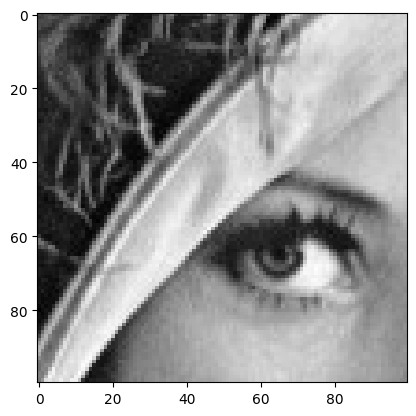

```python
plt.imshow(im_grayscale[200:300, 200:300], cmap='gray');
```

Given a 3 channel image (RGB, CIELAB, HSV, ...) **Could we select one of its channels and use it as a 2D matrix?**

[figure not shown]

```python
plt.imshow(im, cmap="gray");
```

```python
im[200:300, 200:300, :].shape
```

```
(100, 100, 3)
```

### Matrix creation

Methods to create arrays and matrices: https://numpy.org/doc/stable/reference/routines.array-creation.html

```python
np.zeros((4, 4), dtype="float32")
```

```
array([[0., 0., 0., 0.],
       [0., 0., 0., 0.],
       [0., 0., 0., 0.],
       [0., 0., 0., 0.]], dtype=float32)
```

```python
np.ones((5, 5))
```

```
array([[1., 1., 1., 1., 1.],
       [1., 1., 1., 1., 1.],
       [1., 1., 1., 1., 1.],
       [1., 1., 1., 1., 1.],
       [1., 1., 1., 1., 1.]])
```

```python
np.full((5, 5), 7)
```

```
array([[7, 7, 7, 7, 7],
       [7, 7, 7, 7, 7],
       [7, 7, 7, 7, 7],
       [7, 7, 7, 7, 7],
       [7, 7, 7, 7, 7]])
```

```python
np.eye(4, 4)
```

```
array([[1., 0., 0., 0.],
       [0., 1., 0., 0.],
       [0., 0., 1., 0.],
       [0., 0., 0., 1.]])
```

```python
np.random.rand(4, 4)
```

```
array([[0.07383601, 0.19840799, 0.31881768, 0.60903609],
       [0.37759635, 0.4069281 , 0.62825414, 0.4299658 ],
       [0.39271321, 0.93351466, 0.44418588, 0.87824458],
       [0.19151904, 0.50446239, 0.89806376, 0.10551255]])
```

### Matrices operations

Sum, subtraction, multiplication, dot product ... Broadcasting

```python
zeros = np.zeros((4, 4))
zeros
```

```
array([[0., 0., 0., 0.],
       [0., 0., 0., 0.],
       [0., 0., 0., 0.],
       [0., 0., 0., 0.]])
```

```python
zeros + np.full((4,4), 2)
```

```
array([[2., 2., 2., 2.],
       [2., 2., 2., 2.],
       [2., 2., 2., 2.],
       [2., 2., 2., 2.]])
```

```python
zeros + 2
```

```
array([[2., 2., 2., 2.],
       [2., 2., 2., 2.],
       [2., 2., 2., 2.],
       [2., 2., 2., 2.]])
```

```python
np.full((4,4), 2) + np.eye(4, 4)
```

```
array([[3., 2., 2., 2.],
       [2., 3., 2., 2.],
       [2., 2., 3., 2.],
       [2., 2., 2., 3.]])
```

### Linear algebra operations

https://numpy.org/doc/stable/reference/routines.linalg.html

### Statistics operations

https://numpy.org/doc/stable/reference/routines.statistics.html

### Other operations

https://numpy.org/doc/stable/reference/routines.bitwise.html

https://numpy.org/doc/stable/reference/routines.array-manipulation.html (importants)

## Boolean indexing

```python
array = np.random.randint(1, 10, 5)
array
```

```
array([5, 3, 9, 7, 9])
```

```python
array > 4
```

```
array([ True, False,  True,  True,  True])
```

```python
array[array > 4]
```

```
array([5, 9, 7, 9])
```

### Segmenting red gloves using basic operations

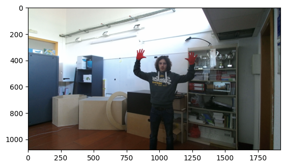

```python
im_guant = cv2.imread("hoi_0000132.png")
im_guant = cv2.cvtColor(im_guant, cv2.COLOR_BGR2RGB)
plt.imshow(im_guant);
```

First of all, I will segment my objective and I will use the image without background

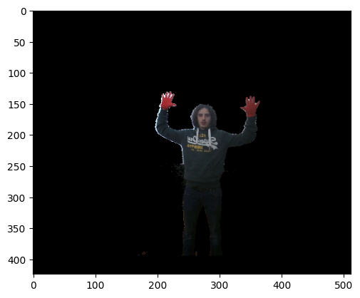

```python
im_guant_noBG = cv2.imread("/content/hoi_0000132_noBackground.png")
im_guant_noBG = cv2.cvtColor(im_guant_noBG, cv2.COLOR_BGR2RGB)
plt.imshow(im_guant_noBG);
```

Now I will grayscale tha image and see how much the gloves will look.

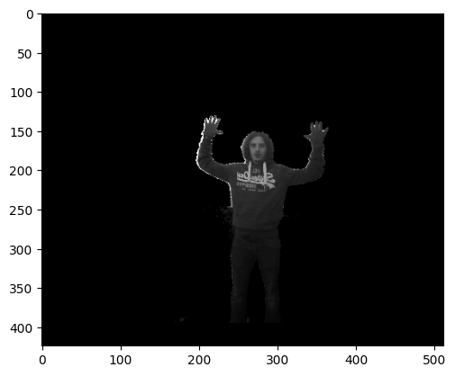

```python
im_guant_noBG_G = cv2.cvtColor(im_guant_noBG,cv2.COLOR_BGR2GRAY)
plt.imshow(im_guant_noBG_G, cmap = "gray");
```

As it can see, the gloves are in the same tone as the much part of the rest of te image, for example the hoodie.

To try something different, I will use the HSV. Using this color model can bring me the option to represent better the red colour in the image due to the channels.

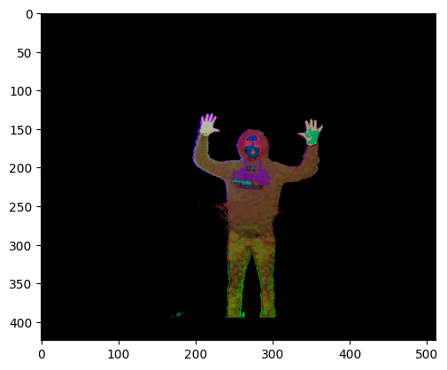

```python
im_guant_HSV = cv2.cvtColor(im_guant_noBG, cv2.COLOR_RGB2HSV)
plt.imshow(im_guant_HSV);
```

Now it can see how the gloves can see different as in the RGB and greyscaled image. For the next step, I will define the range of red colour.

Red can have two ranges in HSV due to the way the hue is structured. So, I will need two masks and then combine them.

The hue component in the HSV color space for OpenCV ranges between 0 to 180. Within this range, the color red is located at the extremes. Specifically, it resides between 0-10 and 160-180. I will use the cv2.inRange() function to create binary masks. This function segments an image based on specified lower and upper bounds. Pixels falling within these bounds are set to white (255), while all other pixels are set to black (0).

Since red spans two separate intervals in the hue channel, we need two distinct masks (mask1 & mask2). After generating them, we combine these masks to get a comprehensive binary representation of all red regions in the image.

```python
# Ranges for the red color
lower_red_1 = np.array([0, 100, 100])
upper_red_1 = np.array([10, 255, 255])

lower_red_2 = np.array([160, 100, 100])
upper_red_2 = np.array([180, 255, 255])

# Masks to detect red
mask1 = cv2.inRange(im_guant_HSV, lower_red_1, upper_red_1)
mask2 = cv2.inRange(im_guant_HSV, lower_red_2, upper_red_2)

# Combine the masks
combined_mask = mask1 + mask2
```

Once the ranges are defined for the red color, and created the masks to detect the red colour, I combined the masks

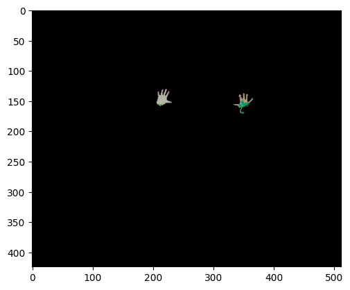

```python
result = cv2.bitwise_and(im_guant_HSV, im_guant_HSV, mask=combined_mask)
plt.imshow(result)
```

These masks helped to identify the gloves to segment them of the rest of the image. That is because separate of hue from brightness and saturation in HSV offers consistent color identification, irrespective of lighting variations. This is especially advantageous for distinguishing colors like red, ensuring accurate detection of objects like the gloves, even under diverse lighting conditions